# Project Report

Krish’s Fanclub

Author

Eli Nacar, Jack McNally, Sam Sword, and Tess Wagner

Published

June 7, 2023

Abstract

*The goal of this project was to develop a model to predict whether a movie would generate revenue or not based on factors associated with the movie. We used Random Forest, Decision Tree, AdaBoost, XGBoost, and Lasso models ensembled with Logistic Regression to create the model that maximized precision the most*.

## 1 Background / Motivation

The film industry is a dynamic landscape where many movies are produced and released each year. However, not all films achieve financial success or resonate with audiences. The ability to accurately predict a movie’s revenue potential before its release can be extremely valuable to filmmakers, investors, and screenwriters, allowing them to make informed decisions and allocate resources such as time and money more effectively.

The predictors considered in this data science project, such as genre, budget, language, and release date, are key factors that influence a movie’s success. Genre plays a role in attracting specific audiences, while budget reflects the financial investment and production values associated with a film. Language can determine the film’s potential global reach and release date affects competition between movies for capturing audiences. Ultimately, the motivation behind this data science project was to use movie data and predictive analytics to enhance decision-making in the film industry, offering a more systematic and evidence-based approach to assessing a movie’s revenue potential.

## 2 Problem statement

Traditionally, the decision-making process in the film industry has been heavily reliant on subjective judgments, making it inherently risky. However, the rise of big data and data science has the potential to revolutionize this approach. With the proliferation of digital platforms and online ticket sales, an enormous amount of data is generated, capturing various attributes of movies.

The primary objective of this project was to develop a model that could accurately determine whether a movie would generate revenue based on a variety of different attributes related to the movie itself. As part of this process in developing a predictive model, one secondary objective was to identify the factors that had the greatest impact on a movie generating revenue. By attaining both of these goals, recommendations could be made to major players in the film industry to improve decision making and movie selection.

## 3 Data sources

The data used was a Kaggle dataset originally from the Full MovieLens Dataset released in July 2017. The dataset includes about 45,000 movies all released before July 2017 along with relevant attributes of these movies such as their budgets, genres, language, and release date. In addition, the dataset has 26 million ratings from around 270,000 people on all of the movies. This data was extracted from the website GroupLens (grouplens.org).

https://www.kaggle.com/datasets/rounakbanik/the-movies-dataset?select=movies_metadata.csv

## 4 Stakeholders

As discussed in our problem statement, there are many relevant stakeholders interested in the ability to predict a movie’s profitability before the actual release of the film.  
1. Movie Studios: If a movie studio is able to utilize our model to predict the profitability of a movie from only a few characteristics such as genre, runtime, and language, movie studios will be able to optimize for those types of movies; thus, choosing to work on the movies that will make them profit.  
2. Actors/Actress: When selecting which movies to act in, our model will allow actors/actress to determine which movies have the most profitable structure (relevant genres/runtime/language/etc…) and; thus, which movies will best further their career and notority in the film industry.  
3. Screenwriters: With our model, a screenwriter will be able to better understand the percevied profitability of their movie. By optimizing their scripts to befit our model, the movies written by a screenwriter are much more likely to be picked up by movie studios and further a screenwriter’s career.

## 5 Data quality check / cleaning / preparation

Because the question we are trying to answer is a classification problem, we had to rework the structure of the response and some of the variables. For example, instead of looking at how much revenue each movie produced, we are predicting whether a movie produced revenue or not. To effectively do this, we changed `revenue` from a continuous variable to a categorical, binary response. We did this for a few of the predictors as well in order to better understand the relationships between the predictors and the response. After parsing through the data, we did not identify any observations that appeared to have incorrect values. While there were a large amount of missing values for `belongs_to_collection`, we identified that a missing value in this column represented a movie that did not belong to a collection. We changed this predictor into a binary variable to fix this issue. There were very few true missing values, and we decided to drop them because they would have been very difficult to impute correctly. For example, it is impossible to come up with a formula to impute missing release dates of movies based on the information of other movies. We decided that dropping these predictions would have a better result on our predictions than trying to impute these values, especially since these observations were a very small portion of the total data.

Distribution of Response (original data):

|  | revenue |
| --- | --- |
| count | 4.546000e+04 |
| mean | 1.120935e+07 |
| std | 6.433225e+07 |
| min | 0.000000e+00 |
| 25% | 0.000000e+00 |
| 50% | 0.000000e+00 |
| 75% | 0.000000e+00 |
| max | 2.787965e+09 |

Distribution of Response (cleaned data):

|  | revenue |
| --- | --- |
| 0.0 | 0.834683 |
| 1.0 | 0.165317 |

#### 5.0.1 Distribution of predictors (original data):

Missing Values (original data):

|  | Missing Values Totals | Unique Values Totals |
| --- | --- | --- |
| belongs_to_collection | 40972 | 1698 |
| budget | 0 | 1226 |
| genres | 0 | 4069 |
| original_language | 11 | 92 |
| release_date | 87 | 17336 |
| runtime | 263 | 353 |

Frequency of Predictors (original data):

|  |  | Top Levels | Frequency |
| --- | --- | --- | --- |
| belongs_to_collection |  | {'id': 415931, 'name': 'The Bowery Boys', 'pos... | 29 |
|  |  | {'id': 421566, 'name': 'Totò Collection', 'pos... | 27 |
|  |  | {'id': 645, 'name': 'James Bond Collection', '... | 26 |
| budget |  | 0 | 36573 |
|  |  | 5000000 | 286 |
|  |  | 10000000 | 259 |
| genres |  | [{'id': 18, 'name': 'Drama'}] | 5000 |
|  |  | [{'id': 35, 'name': 'Comedy'}] | 3621 |
|  |  | [{'id': 99, 'name': 'Documentary'}] | 2723 |
| original_language |  | en | 32269 |
|  |  | fr | 2438 |
|  |  | it | 1529 |
| release_date |  | 2008-01-01 | 136 |
|  |  | 2009-01-01 | 121 |
|  |  | 2007-01-01 | 118 |
| runtime |  | 90.0 | 1558 |
|  |  | 0.0 | 107 |
|  |  | 100.0 | 33 |

*(See project code for the frecuency of levels table for the cleaned data)*

## 6 Exploratory data analysis

Movies with larger budgets seemed to have a better chance of making a profit than movies with smaller budgets. Movies with shorter run times seemed to have a better chance of making a profit. These two predictors were identified as having high importances by some of our individual models. These relationships were helpful to recognize that these predictors were potentially more influential than others in our models.

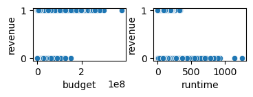

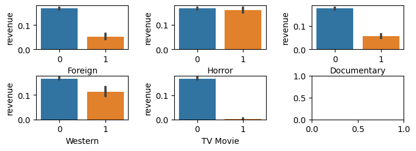

## 7 Approach

With our model choices, we hoped to develop a deep and varied selection of models for ultimate ensembles. In these models, we optimized for both accuracy and precision. This was because, for our stakeholders, predicting a movie to be profitable when it is not it much more devastating than predicting a movie to not be profitable while it actually is. By optimizing accuracy and prediction, we ensure our model’s election of the positive class (a movie being profitable) is trustworthy. Our approach is very traditional, focusing on EDA insights and hyperparameter tunings to optimize our models. With a plentiful data source and direct approach, we did not anticipate many issues with our model creation. As anticipated, we did not run into many issues during the creation of our model; however, we did run into many unanticipated outcomes, primarily, the models that we believed would be successful and those that actually found success. Our problem did not have any prior solutions. We did not utilize any code repositories.

## 8 Developing the model: Hyperparameter tuning

### 8.1 RandomForest

*By Elijah Nacar*

To begin, I split the data into a train/testing split and scaled/imputed the data. I began with the parameter grid shown below and found great success with a model accuracy of ~87.56% and a model precision of ~66.48%.

```
params=  (2000, 1, 15, 2, 45)
```

After this initial tuning, I noticed that both max_depth and max_leaf_nodes selected the highest value possible for their hyperparameter. I chose to tune these parameters further as I believed it would be the most beneficial way to improve the model with only an assignment’s-worth of time.

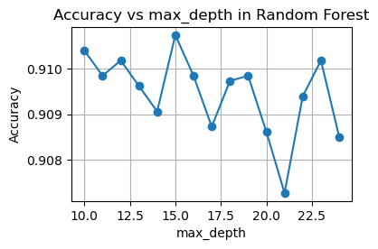

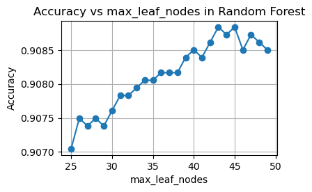

I then used the new hyperparameters found by using this approach (max_depth = 15 | max_leaf_nodes = 45) to tune the decision threshold probability. With a decision threshold of 0.38, my model was able to achieve an accuracy of ~86.09% and a precision ~91.54%. A slight decrease in a accuracy for a massive increase in precision.

```
Accuracy:  86.08501118568232
Precision:  0.9154929577464789
```

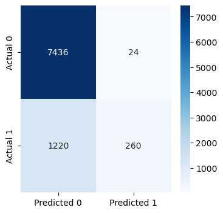

### 8.2 AdaBoost

*By Jack McNally*

```
Best: 0.806693 using {'base_estimator': DecisionTreeClassifier(max_depth=3), 'learning_rate': 0.01, 'n_estimators': 1}
```

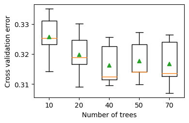

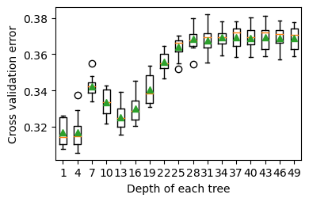

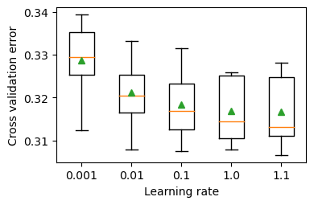

```
Best: 0.798358 using {'base_estimator': DecisionTreeClassifier(max_depth=3), 'learning_rate': 0.001, 'n_estimators': 25}
```

For hyperparameter tuning, I first started with a coare search to get a foundational understanding of what hyperparameters would be most optimal. I then proceeded to tune the number of trees, the depth of the model, and the learning rates individually. I took this approach as the computational time was significantly less, while also allowing me to fine tune one parameter at a time. After finding the optimal values for each hyperparameter, I then performed a fine tuned search where each range of values considered surrounded the optimal values I had previously found. I took this approach so that my grid search could find the best hyperparameter combinations when considered in unison. After this fine tuned search, I felt confident about my results as minor changes to the parameters did not improve my precision accuracy.

### 8.3 Decision Tree

*By Tess Wagner*

```
DecisionTreeClassifier(random_state=1)
```

```
Accuracy:  0.8502069582727374
Precision:  0.5462889697736983
Recall:  0.5810469617909443
```

```
Maximum tree depth = 34
Maximum leaves = 4737
```

```
Fitting 5 folds for each of 1680 candidates, totalling 8400 fits
```

```
GridSearchCV(cv=StratifiedKFold(n_splits=5, random_state=1, shuffle=True),
             estimator=DecisionTreeClassifier(random_state=1), n_jobs=-1,
             param_grid={'max_depth': range(2, 34, 5),
                         'max_features': range(1, 26, 5),
                         'max_leaf_nodes': range(2, 4737, 100)},
             scoring='precision', verbose=1)
```

```
0.7774043203107854 {'max_depth': 7, 'max_features': 16, 'max_leaf_nodes': 102}
```

After the original grid search, I did a finer grid search based on the top combinations of values returned by the original grid search. I chose to do another grid search because the original range of values was very wide, and I thought I would try to get a higher training precision.

```
Fitting 5 folds for each of 315 candidates, totalling 1575 fits
```

```
GridSearchCV(cv=KFold(n_splits=5, random_state=1, shuffle=True),
             estimator=DecisionTreeClassifier(random_state=1), n_jobs=-1,
             param_grid={'max_depth': range(7, 17, 2),
                         'max_features': range(16, 29, 2),
                         'max_leaf_nodes': range(90, 300, 25)},
             scoring='precision', verbose=1)
```

```
0.7836584372111675 {'max_depth': 9, 'max_features': 20, 'max_leaf_nodes': 140}
```

```
DecisionTreeClassifier(max_depth=9, max_features=20, max_leaf_nodes=140,
                       random_state=1)
```

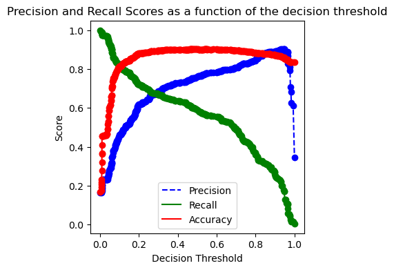

|  | thresholds | precision | recall | accuracy |
| --- | --- | --- | --- | --- |
| 347 | 0.947368 | 0.90417 | 0.172449 | 0.8598 |

```
Accuracy:  0.8603031659022262
ROC-AUC:  0.9089531201557569
Precision:  0.9730848861283644
Recall:  0.1590793704518531
```

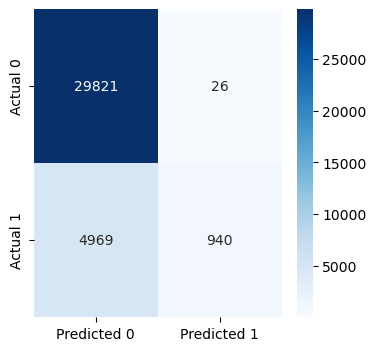

```
Test Accuracy:  0.8562639821029083
Test ROC-AUC:  0.8878818563872182
Test Precision:  0.9148936170212766
Test Recall:  0.14527027027027026
```

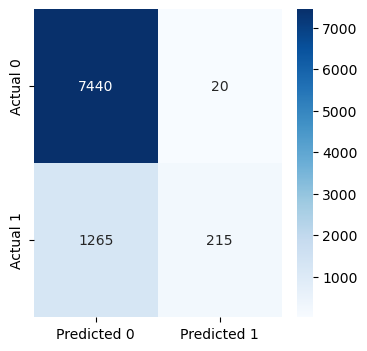

The cross validated training accuracy of the tuned model has stayed about the same, the training recall has decreased by about 43%, and the training precision has improved by about 43% compared to the base model. There were only 20 movies that were predicted to produce revenue and did not with this model.

After finding the optimal hyperparameters using grid searches, I used cost-complexity pruning to find the optimal `ccp_alpha`. Next, I found the optimal decsision threshold probability to maximize precision. When using this decision threshold, this model predicted every observation as 0. In the process of trying to maximize precision, this model became too conservative. Using this cutoff is not useful because main idea of our project is to determine which movies will produce revenue. After choosing the threshold with the highest precision that didn’t only predict zeros, the cross validated training precision was about 14% lower than the precision of the model with the tuned hyperparameters.

I tried one more model where I used a grid search to find the optimal `ccp_alpha` and the optimal hyperparameters simultaneously. After tuning the decision threshold probability with the cross validated training predictions, the training precision was still slightly lower than the training precision of the model with just the tuned hyperparameters. Ultimately, the model with only the tuned hyperparameters had the best performance.

### 8.4 XGBoost

*By Samuel Sword*

```
Test data performance metrics (with decision threshold of 0.818):
Accuracy:  88.5234899328859
Precision:  0.8982456140350877
```

The naive model performs fairly well; however, hyperparameter tuning was done to optimize the model.

```
Fitting 5 folds for each of 200 candidates, totalling 1000 fits
```

```
{'scale_pos_weight': 1.25, 'reg_lambda': 100, 'n_estimators': 100, 'max_depth': 6, 'learning_rate': 0.3, 'gamma': 0} 0.9068128681178177
Time taken =  7.520998700459798  minutes
```

```
Test data performance metrics:
Accuracy:  88.87024608501119
Precision:  0.9307282415630551
```

#### 8.4.1 LassoCV model

Naive model:

```
Test data performance metrics:
Accuracy:  88.46756152125279
Precision:  0.8931698774080561
```

Tuning of the hyperparameter C yielded minimal success:

```
Test data performance metrics:
Accuracy:  88.46756152125279
Precision:  0.8945518453427065
```

## 9 Model Ensemble

### 9.1 Voting ensemble

```
Test data performance metrics of ensemble:
Accuracy:  87.88590604026845
Precision:  0.93058568329718
```

### 9.2 Stacking ensemble

*By Tess Wagner*

```
Best value of max_features= 1
```

```
StackingClassifier(cv=StratifiedKFold(n_splits=5, random_state=1, shuffle=True),
                   estimators=[('model_ada',
                                AdaBoostClassifier(estimator=DecisionTreeClassifier(max_depth=3),
                                                   learning_rate=0.001,
                                                   n_estimators=25,
                                                   random_state=1)),
                               ('model_xgb',
                                XGBClassifier(base_score=None, booster=None,
                                              callbacks=None,
                                              colsample_bylevel=None,
                                              colsample_bynode=None,
                                              colsample_byt...
                                DecisionTreeClassifier(max_depth=9,
                                                       max_features=20,
                                                       max_leaf_nodes=140,
                                                       random_state=1)),
                               ('model_rf',
                                RandomForestClassifier(max_depth=15,
                                                       max_features=1,
                                                       max_leaf_nodes=45,
                                                       n_estimators=2000,
                                                       random_state=1)),
                               ('model_lasso',
                                LogisticRegression(C=0.1, penalty='l1',
                                                   solver='liblinear'))],
                   final_estimator=LogisticRegression(C=1, max_iter=1000,
                                                      random_state=1),
                   n_jobs=-1)
```

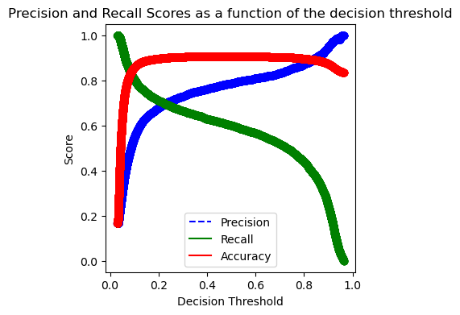

|  | thresholds | precision | recall | accuracy |
| --- | --- | --- | --- | --- |
| 35649 | 0.963630 | 1.0 | 0.000169 | 0.834741 |
| 35580 | 0.958021 | 1.0 | 0.011846 | 0.836671 |

```
Test Accuracy:  0.8370246085011186
Test ROC-AUC:  0.9101119484095355
Test Precision:  1.0
Test Recall:  0.015540540540540541
```

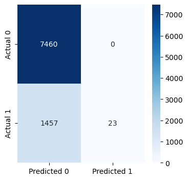

## 10 Limitations of the model with regard to prediction

While our team did find great success optimizing for our performance metrics (accuracy and precision), with more time or resources, we believe there is potential for each of our individual models to be better tuned to the input data. While we did utilize EDA, with more time, we could cater specific EDA to each of our models (i.e which predictors are best for XGBoost, Random Forest, etc…) and likely better prepare our data for our models. Additionally, with more time, we could allocate more resources to tuning the models and ensure we are utilizing the best hyperparameters available.

In terms of convenience, all of our stakeholders (movie studios, actors/actresses, and screenwriters) should have easy access to the relevant predictors in our model as each party has access to a movie’s script. With our model, as soon as a script is finalized with runtime, language, and the related, our stakeholders should be able to predict whether the movie script they are analyzing will be profitable or not.

Inherently, when discussing a movie’s profitability, there is always a consideration for popular culture of the time and what is profitable during a breadth of years. With changes to popular culture and what audiences want, our model will need to be retrained on more representative data. This limiation is constant as we cannot predict what external changes will occur and their impact on movie viewing; thus, our current will become obselete once a cultural shift occurs in movie viewing and popularity. Hopefully, by retraining our model on newer data, our model can continue to be relevant through these cultural shifts.

## Individual contribution

| Team member | Individual Model | Work other than individual model | Details of work other than individual model |
| --- | --- | --- | --- |
| Elijah Nacar | RandomForestClassifier | Data Search and Performance Metrics | Searched for data sources and determined performance metrics |
| Jack McNally | AdaBoost | Variable selection | Variable selection based on feature importance |
| Tess Wagner | Decision Tree | Data Cleaning, EDA, Ensembling | Transformed response/predictors, Created tables/plots of variable distributions, Stacking Ensemble |
| Sam Sword | XGBoost and Lasso | Ensembling | Voting ensemble |